# Laboratorio 4

Daniel Arturo Lopez Sanchez

11/3/2020

## Problema 1

Se tienen las resistencias de cables fabricados con 2 aleaciones distintas I y II (ver la tabla de abajo). Se quiere decidir si hay o no diferencia de las muestras, o sea, si proceden o no de la misma población. Además, determinar si hay diferencia respecto a la resistencia mediana entre los cables de las aleaciones I y II (supóngase α =0.05 para ambos casos).

```r
library(e1071)
Aleacion1 <- c(18.3, 16.4, 22.7, 17.8, 18.9, 25.3, 16.1, 24.2)
n1 <- length(Aleacion1)
Aleacion2 <- c(12.6, 14.1, 20.5, 10.7, 15.9, 19.6, 12.9, 15.2, 11.8, 14.7)
n2 <- length(Aleacion2)
```

Debido a que las muestras son independientes y de diferente tamaño, se usará una prueba de Mann Whitney Wilcoxon.

Comprobando supuestos

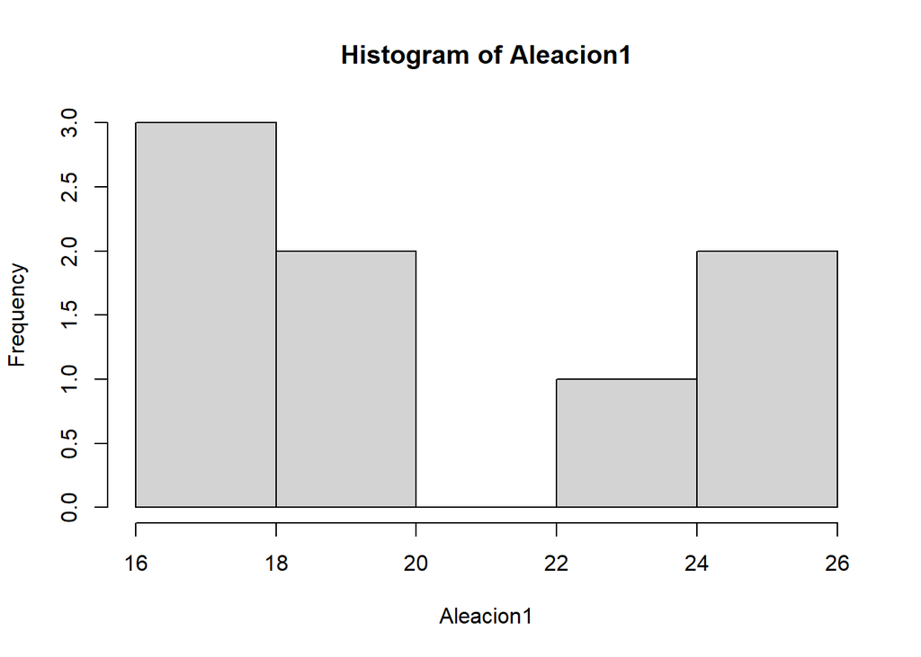

```r
hist(Aleacion1)
```

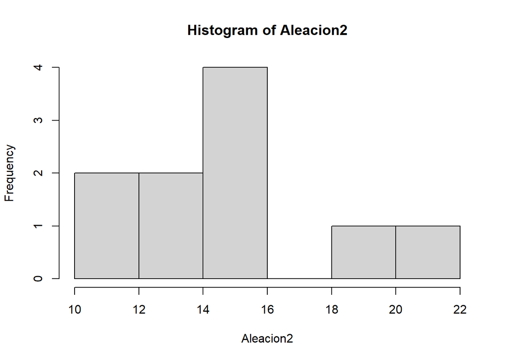

```r
hist(Aleacion2)
```

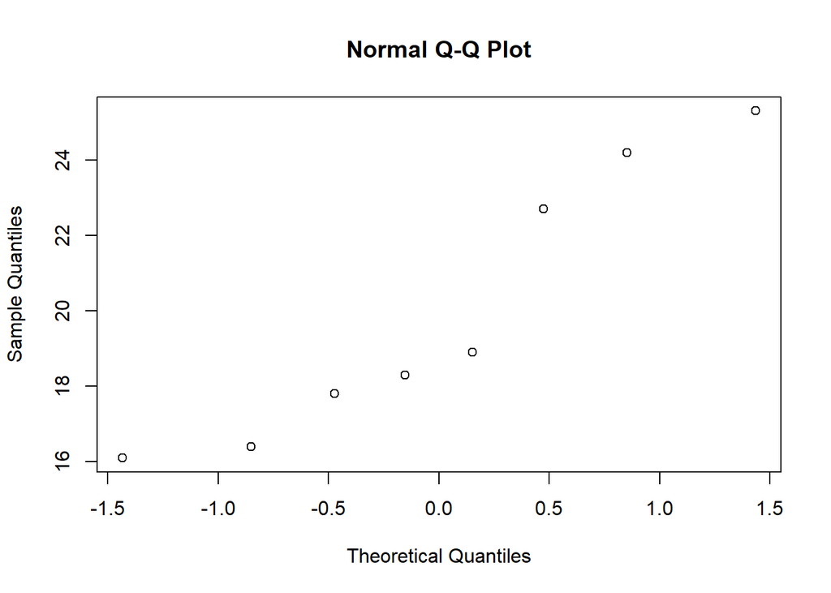

```r
qqnorm(Aleacion1)
```

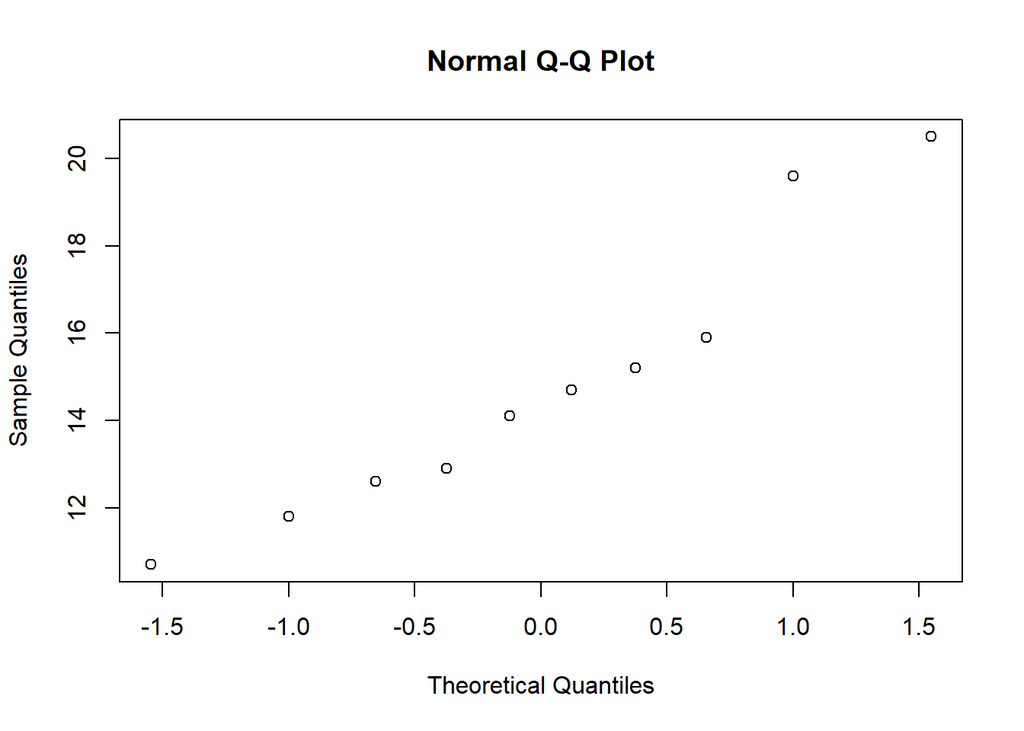

```r
qqnorm(Aleacion2)
```

```r
cat("Coeficiente de asimetria Aleacion 1:", skewness(Aleacion1), "\n",
    "Coeficiente de Curtosis Aleacion 1:", kurtosis(Aleacion1))
```

```
## Coeficiente de asimetria Aleacion 1: 0.3515682
##  Coeficiente de Curtosis Aleacion 1: -1.789813
```

```r
cat("Coeficiente de asimetria Aleacion 2:", skewness(Aleacion2), "\n",
    "Coeficiente de Curtosis Aleacion 2:", kurtosis(Aleacion2))
```

```
## Coeficiente de asimetria Aleacion 2: 0.5643029
##  Coeficiente de Curtosis Aleacion 2: -1.083157
```

Las muestras no parecen tener una forma idéntica por lo que no podemos hablar de medianas. Por esta razón las Hipótesis quedarán de la siguiente manera:

HIPOTESIS * H0: Las dos poblaciones son idénticas * Ha: Las dos poblaciones no son idénticas

Nuestro nivel de significancia (alfa) será de 0.05

CALCULOS

```r
rangos <- rank(x = c(Aleacion1,Aleacion2), ties.method = "average")
rangos_A1 <- rangos[1:8]
rangos_A2 <- rangos[9:18]
W <- sum(rangos_A1)
```

W se puede aproximar a una distribucion normal porque ambas muestras son mayor a 7

```r
media_W <- (1/2) * (n1*(n1+n2+1))
sd_W <- sqrt((1/12) * (n1*n2*(n1+n2+1)))

valor_p <- pnorm(q = W-0.5, mean = media_W, sd = sd_W, lower.tail = F)*2
cat("valor-p:", valor_p)
```

```
## valor-p: 0.008763529
```

*Con una significancia de 0.05, podemos afirmar que las muestras provienen de distintas poblaciones, es decir, las poblaciones no son identicas.*

## Problema 2

Un profesor de psicología tiene 2 clases, se toma una muestra aleatoria de la clase de la mañana de 9 estudiantes y otra en la tarde de 12 estudiantes. En un examen común a todos ellos, las notas fueron las que se recoge en la tabla de abajo. ¿Se puede concluir al nivel de significancia de 0.05 que la clase de la mañana es peor que la clase de la tarde? ¿Qué puede concluir con el nivel de significancia dado?

```r
Clase_matinal <- c(73, 87, 79, 75, 82, 66, 95, 75, 70)
n1 <- length(Clase_matinal)
Clase_vesp <- c(86, 81, 84, 88, 90, 85, 84, 92, 83, 91, 53, 84)
n2 <- length(Clase_vesp)
```

Debido a que las muestras son independientes y de diferente tamaño, se usará una prueba de Mann Whitney Wilcoxon.

Comprobando supuestos

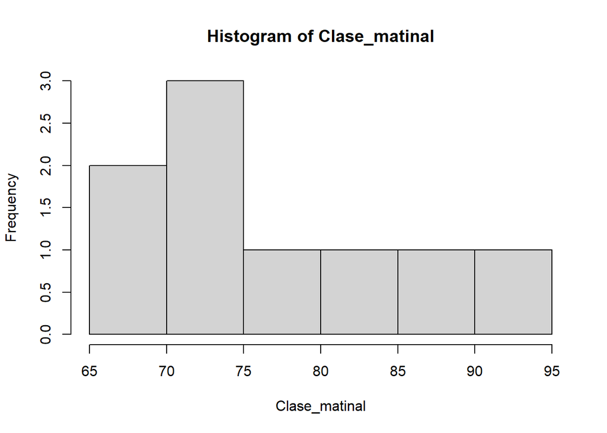

```r
hist(Clase_matinal)
```

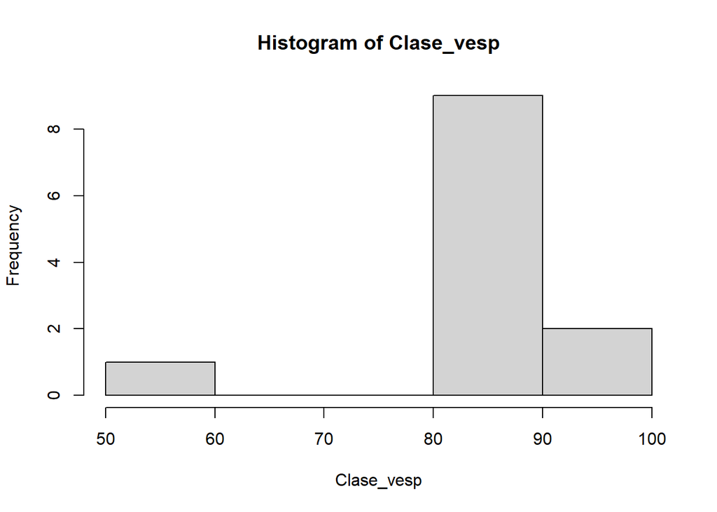

```r
hist(Clase_vesp)
```

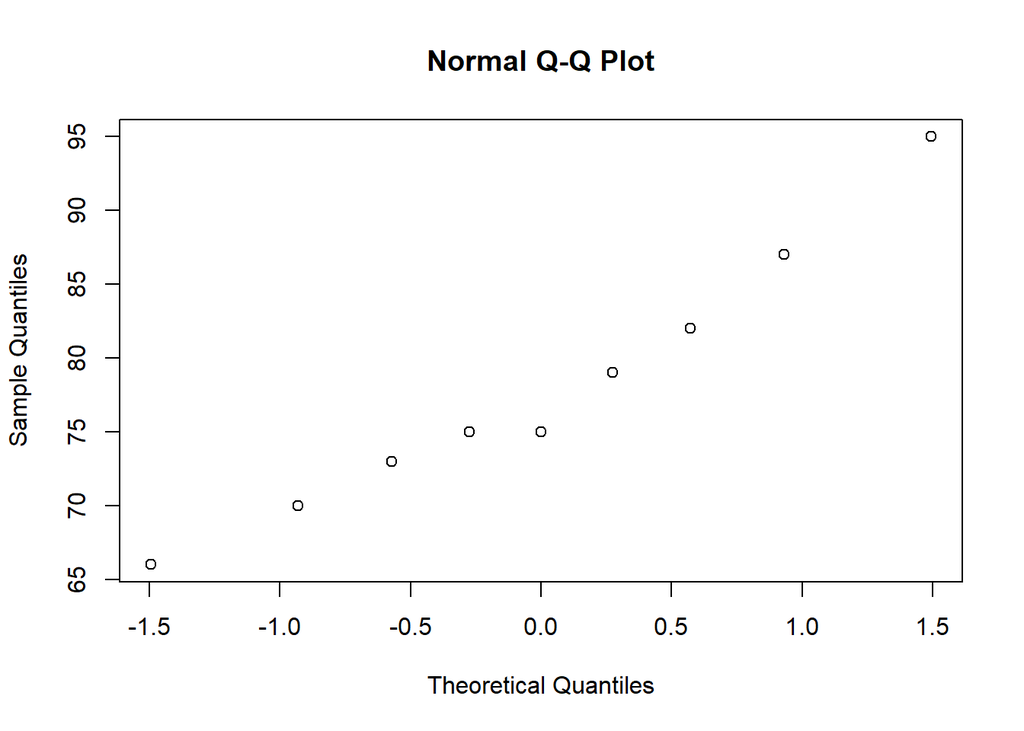

```r
qqnorm(Clase_matinal)
```

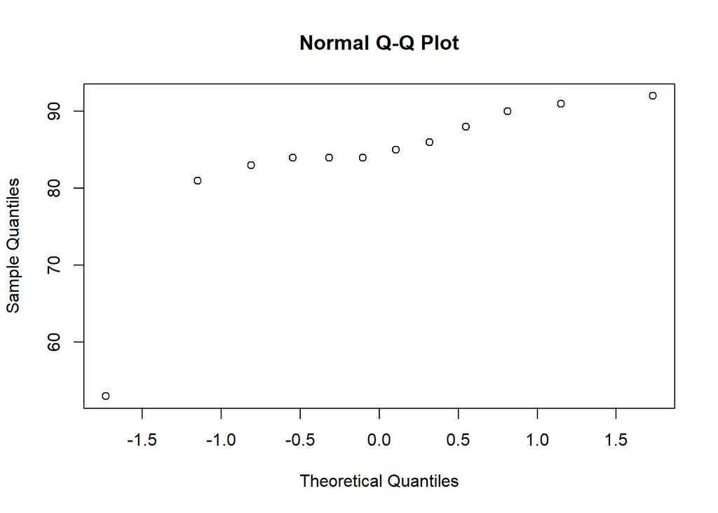

```r
qqnorm(Clase_vesp)
```

```r
cat("Coeficiente de asimetria Clase matinal:", skewness(Clase_matinal), "\n",
    "Coeficiente de Curtosis Clase matinal:", kurtosis(Clase_matinal))
```

```
## Coeficiente de asimetria Clase matinal: 0.5129715
##  Coeficiente de Curtosis Clase matinal: -0.9741988
```

```r
cat("Coeficiente de asimetria Clase vespetina:", skewness(Clase_vesp), "\n",
    "Coeficiente de Curtosis Clase vespertina:", kurtosis(Clase_vesp))
```

```
## Coeficiente de asimetria Clase vespetina: -2.116166
##  Coeficiente de Curtosis Clase vespertina: 3.764085
```

Las muestras no parecen tener una forma idéntica por lo que no podemos hablar de medianas. Por esta razón las Hipótesis quedarán de la siguiente manera:

HIPOTESIS: * H0: La clase matinal es igual o mejor que la clase vespertina. * Ha: La clase matinal es peor que la clase vespertina.

Nuestro nivel de significancia (alfa) será de 0.05

CALCULOS

```r
rangos <- rank(c(Clase_matinal,Clase_vesp), ties.method = "average")
rangos_CM <- rangos[1:9]
rangos_CV <- rangos[10:21]
W <- sum(rangos_CM)

# W se puede aproximar a una distribucion normal porque ambas muestras son mayor a 7
mean_W <- (1/2) * (n1*(n1+n2+1))
sd_W <- sqrt((1/12) * (n1*n2*(n1+n2+1)))

valor_p <- pnorm(q = W, mean = mean_W, sd = sd_W)
cat("valor-p:", valor_p)
```

```
## valor-p: 0.03232002
```

*Con una significancia de 0.05 se puede afirmar que la clase matinal es peor que la vespertina.*

## Problema 4

Una empresa quiere comprar una de las 5 máquinas distintas A, B, C, D, E. En un experimento diseñado para saber si hay diferencia en la eficiencia de tales máquinas, 5 operarios expertos trabajando cada uno con las máquinas un mismo tiempo en cada una. Los resultados se recogen en la tabla de abajo, en número de unidades producidas. Contrastar la hipótesis de que no hay diferencia significativa entre ellas a nivel de significancia a) 0.05 y b) 0.1. Supóngase que las poblaciones tienen la misma forma

```r
A <- c(68,72,77,42,53)
B <- c(72,53,63,53,48)
C <- c(60,82,64,75,72)
D <- c(48,61,57,64,50)
E <- c(64,65,70,68,53)
```

Se utilizara una prueba de Kruskal Wallis, pues las muestras son mas de dos e independientes.

HIPOTESIS: * H0: Todas las maquinas son iguales * Ha: Por lo menos una maquina es distinta al resto.

CALCULOS

```r
n1 <- length(A)
n2 <- length(B)
n3 <- length(C)
n4 <- length(D)
n5 <- length(E)
rangos <- rank(x = c(A,B,C,D,E), ties.method = "average")
rangosA <- rangos[1:5]; SumaRangosA <- sum(rangosA)
rangosB <- rangos[6:10]; SumaRangosB <- sum(rangosB)
rangosC <- rangos[11:15]; SumaRangosC <- sum(rangosC)
rangosD <- rangos[16:20]; SumaRangosD <- sum(rangosD)
rangosE <- rangos[21:25]; SumaRangosE <- sum(rangosE)
Nt <- n1+n2+n3+n4+n5

H <- (12/(Nt*(Nt+1)))*((SumaRangosA^2+SumaRangosB^2+SumaRangosC^2+SumaRangosD^2+SumaRangosE^2)/n1)-(3*(Nt+1))

valor_p <- pchisq(q = H, df = 4, lower.tail = F)
valor_p
```

```
## [1] 0.1682939
```

## Problema 5

Se toman al azar 3 muestras de una población. Al ordenar los datos de acuerdo con el rango se obtiene la tabla de abajo. Determine si hay diferencia entre las muestras al nivel de significancia a) 0.05 y b) 0.01.

```r
RangosM1 <- c(7,4,6,10,13,16)
RangosM2 <- c(11,9,12,14,15)
RangosM3 <- c(5,1,3,8,2,17)
n1 <- length(RangosM1); n2 <- length(RangosM2)
n3 <- length(RangosM3)
```

Se utilizara una prueba de Kruskal Wallis, pues se tienen los rangos de 3 muestras independientes.

HIPOTESIS: * H0: Todas las poblaciones son iduales * Ha: Por lo menos una poblacion es diferente.

Significancia: * a) 0.05 * b) 0.01

```r
SumaRangosM1 <- sum(RangosM1)
SumaRangosM2 <- sum(RangosM2)
SumaRangosM3 <- sum(RangosM3)
Nt <- n1+n2+n3
H <- (12/(Nt*(Nt+1)))*(SumaRangosM1^2/n1 + SumaRangosM2^2/n2 + SumaRangosM3^2/n3)-(3*(Nt+1))
pvalue <- pchisq(q = H, df = 2, lower.tail = F)
pvalue
```

```
## [1] 0.1254539
```

*Con una significancia de 0.05 (a) y 0.01 (b), no se tiene suficiente evidencia para afirmar que existe una diferencia en por lo menos una de las poblaciones.*

## Problema 6

Como nuevo gerente de las cuentas de Pox Skin Ointment, debe compara el tiempo que les toma a los 3 clientes pagar los envíos de No-Flaw-Face Cream, un nuevo producto ofrecido por Pox. Se selecciona aleatoriamente varias compras de cada cliente, junto con el número de días que cada uno se tomó en liquidar su cuenta. Los resultados están en la tabla de abajo. Determine si hay diferencia en los tiempos que toma a los 3 clientes cancelar sus cuentas con Pox (𝛼=0.05). Supóngase las poblaciones tienen la misma forma.

```r
Cliente1 <- c(28,19,13,28,29,22,21)
Cliente2 <- c(26,20,11,14,22,21)
Cliente3 <- c(37,28,26,35,31)
n1 <- length(Cliente1); n2 <- length(Cliente2)
n3 <- length(Cliente3)
```

Se utilizara una prueba de Kruskal Wallis pues las muestras son indepenientes.

HIPOTESIS: * H0: El tiempo de los 3 clientes es el mismo * Ha: Por lo menos un cliente tiene tiempo distinto

Significancia 0.05

CALCULOS

```r
rangos <- rank(x = c(Cliente1,Cliente2,Cliente3))
rangosCliente1 <- rangos[1:7]; SumaRangosCliente1 <- sum(rangosCliente1)
rangosCliente2 <- rangos[8:13]; SumaRangosCliente2 <- sum(rangosCliente2)
rangosCliente3 <- rangos[14:18]; SumaRangosCliente3 <- sum(rangosCliente3)
Nt <- n1+n2+n3

H <- (12/(Nt*(Nt+1)))*(SumaRangosCliente1^2/n1 + SumaRangosCliente2^2/n2 + SumaRangosCliente3^2/n3)-(3*(Nt+1))
pvalue <- pchisq(q = H, df = 2, lower.tail = F)
pvalue
```

```
## [1] 0.01675749
```

*Con una significancia de 0.05, podemos concluir que existe una diferencia significativa en el tiempo de por lo menos uno de los clientes.*

## Problema 7

En la tabla de abajo, se muestra cómo fueron calificados 10 estudiantes de un curso de Biología, según rango, ordenados por letra alfabética, en un laboratorio y en teoría. Hallar el coeficiente de correlación de rango y determine si existe relación entre las calificaciones del laboratorio y de la teoría en el curso de Biología (𝛼=0.05).

```r
Laboratorio <- c(8,3,9,2,7,10,4,6,1,5)
Teoria <- c(9,5,10,1,8,7,3,4,2,6)
```

Se hara una prueba de correlacion de rangos para verificar si existe una relacion entre las calificaciones del laboratorio con la teoria.

Parametro de interes: Rho s (Coeficiente de correlacion pob.)

HIPOTESIS * H0: Rho == 0 * Ha: Rho != 0

Significancia: 0.05

CALCULOS

```r
Rs_num <-  sum((Laboratorio-mean(Laboratorio))*(Teoria-mean(Teoria)))
Rs_denom <- sqrt(sum((Laboratorio-mean(Laboratorio))^2)*sum((Teoria-mean(Teoria))^2))
Rs <- Rs_num/Rs_denom
SD_Rs <- sqrt(1/9)

pvalue <- 2*pnorm(q = Rs, mean = 0, sd = SD_Rs, lower.tail = F)
pvalue
```

```
## [1] 0.0103582
```

*Con una significancia de 0.05, podemos afirmar que si hay una correlacion entre calificaciones de Laboratorio con Teoria.*

## Problema 8

En la tabla aparecen las alturas de una muestra de 12 padres y sus hijos mayores. Hallar el coeficiente de correlación de rangos y determinar si existe relación ente las alturas de padre e hijo mayor (𝛼=0.05).

```r
Padre <- c(65,63,67,64,68,62,70,66,68,67,69,71)
Hijo <- c(68,66,68,65,69,66,68,65,71,67,68,70)
rangosPadre <- rank(Padre)
rangosHijo <- rank(Hijo)
```

Se hara una prueba de correlacion de rangos para comprobar si hay relacion de estatura entre padre e hijo.

Parametro de interes: Rho s (Coef. de correlacion Pob.)

HIPOTESIS: * H0: Rho == 0 * Ha: Rho != 0

Significancia: 0.05

CALCULOS

```r
Rs_num <-  sum((rangosPadre-mean(rangosPadre))*(rangosHijo-mean(rangosHijo)))
Rs_denom <- sqrt(sum((rangosPadre-mean(rangosPadre))^2)*sum((rangosHijo-mean(rangosHijo))^2))
Rs <- Rs_num/Rs_denom
SD_Rs <- sqrt(1/11)

pvalue <- 2*pnorm(q = Rs, mean = 0, sd = SD_Rs, lower.tail = F)
pvalue
```

```
## [1] 0.01408171
```

*Con una significancia de 0.05, podemos afirmar que existe una relacion entre las estaturas de los padres con la de los hijos mayores.*